# mPower: A Real Data-based Power Analysis Tool for Microbiome Study Design

2024-07-17

This package estimates the power for microbiome study design based on various experimental designs and parameters. For details of the proposed method, please refer to the following paper: Lu Yang, Jun Chen. mPower: A Real Data-based Power Analysis Tool for Microbiome Study Design

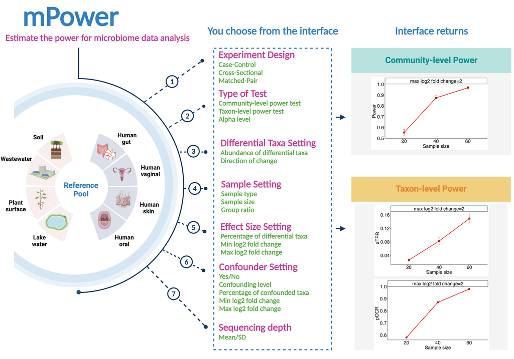

## 1. Usage

### 1.1 Package installation

You can install mPower as follows:

```r
# install.packages("devtools")
devtools::install_github("chloelulu/mPower")
```

### 1.2 Shiny R App

You can also use our Shiny App without coding skills, please access the Shiny App at: https://microbiomestat.shinyapps.io/mPower/

## 2. Examples

Assume you are designing a case-control gut microbiome study (e.g., cancer vs healthy individuals) and want to determine the sample size needed to achieve 80% community-level and taxa-level power. Assume a log 2 fold change of 2 based on the literature.

```r
library(reactable) # show table in Markdown
library(mPower)
data(feature.dat)
```

Exclude features present in fewer than 2 samples

```r
feature.dat <- feature.dat[rowSums(feature.dat != 0) > 2, ]
```

Estimate the parameters

```r
model.paras <- EstPara(ref.otu.tab = feature.dat)
```

#### 2.1 Estimate Community-Level Power for Case-Control Study

```r
res1 <- mPower(feature.dat = feature.dat, model.paras = model.paras,
               test = 'Community', design = 'CaseControl',
               nSams = 50, grp.ratio = 0.5,
               iters = 500, alpha = 0.05, distance = 'BC',
               diff.otu.pct = 0.1, diff.otu.direct = 'balanced',diff.otu.mode = 'random',
               covariate.eff.min = 0, covariate.eff.maxs = c(1, 2),
               confounder = 'no', depth.mu = 10000, depth.theta = 5, verbose = F)
```

##### 2.1.1 Output1: Community-level power table (“power” column indicates community-level power)

| Sample size | max log2 fold change | power | SD | ymax | ymin |
| --- | --- | --- | --- | --- | --- |
| 50 | 1 | 0.408 | 0.491955323256251 | 0.451121785351999 | 0.364878214648001 |
| 50 | 2 | 0.786 | 0.410537552684682 | 0.821985203104679 | 0.750014796895321 |

##### 2.1.2 Output2: R2 (variance explained) and community-level power curve

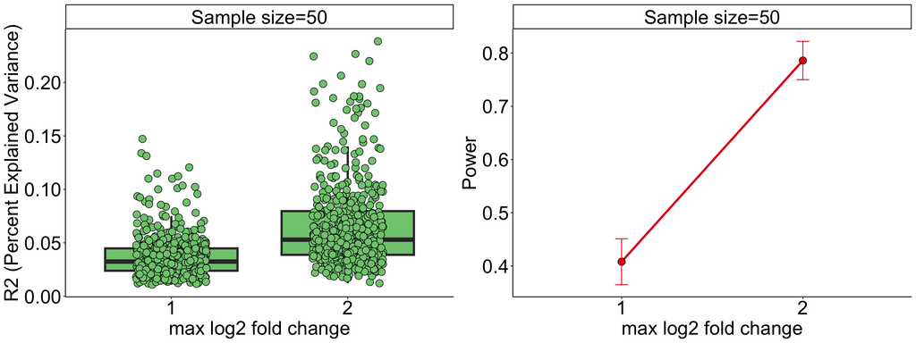

#### 2.2 Estimate Taxa-Level Power for Case-Control Study

```r
res2 <- mPower(feature.dat = feature.dat, model.paras = model.paras,
               test = 'Taxa', design = 'CaseControl',
               nSams = c(20, 80), grp.ratio = 0.5,
               iters = 50, alpha = 0.05, distance = 'BC',
               diff.otu.pct = 0.1, diff.otu.direct = 'balanced',diff.otu.mode = 'random',
               covariate.eff.min = 0, covariate.eff.maxs = 2,
               prev.filter = 0.1, max.abund.filter = 0.002,
               confounder = 'yes', depth.mu = 100000, depth.theta = 5, verbose = F)
```

##### 2.2.1 Output1: Taxa-level power table (“pOCR” column indicates the probability of making at least one correct rejection)

| Sample size | max log2 fold change | pOCR |
| --- | --- | --- |
| 20 | 2 | 0.38 |
| 80 | 2 | 0.94 |

##### 2.2.2 Output2: Taxa-level power table (“aTPR” column indicates the average true positive rate)

| Sample size | max log2 fold change | aTPR | SD | ymax | ymin |
| --- | --- | --- | --- | --- | --- |
| 20 | 2 | 0.0275998670792721 | 0.0420055892771984 | 0.0392432223933245 | 0.0159565117652197 |
| 80 | 2 | 0.0999980510775839 | 0.0621544864419737 | 0.117226395744544 | 0.0827697064106234 |

##### 2.2.3 Output3: aTPR power curve(left) and pOCR power curve(right)

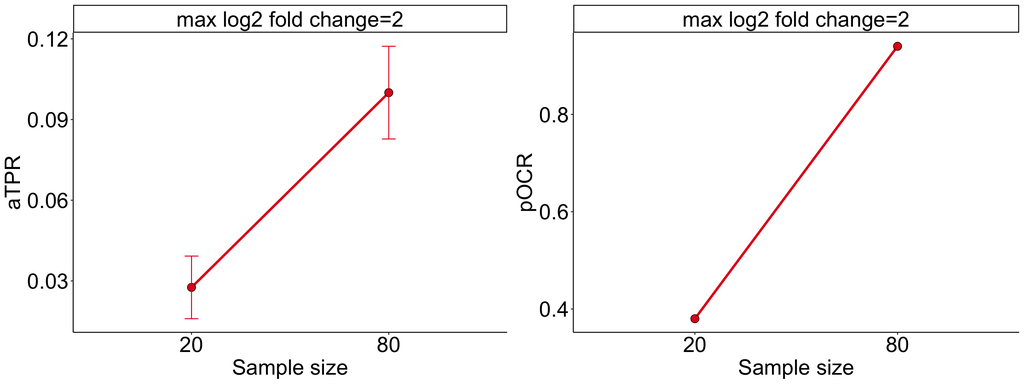